# Final Project

Group 6

2024-12-06

# Introduction

Amphibian populations face significant threats from habitat loss, climate change, and direct human activities, such as road mortality. To lessen the impact of roads, amphibian road-crossing brigades have become a vital conservation effort. These initiatives involve volunteers assisting amphibians in safely crossing roads during their migratory periods in an attempt to reduce mortality and preserve the local populations (Valentine-Darby (2024)).

On the first rainy night in the springtime, when the temperature is between 45 and 50 degrees fahrenheit, hundreds of thousands of amphibians abandon their underground burrows and make the journey to vernal pools for breeding (Audubon (2024)). The mass migration of amphibian species that occurs each spring is referred to as “The Big Night” and attracts spectators from all over the Northeast (Audubon (2024)). The amphibians remain at the vernal pool for anywhere from a few days to weeks, with the males courting mates in a mass courtship ritual known as congressing. The males use their calls in an attempt to attract mates and the females lay their eggs in the vernal pools, and once this process is over, the amphibians return to their forest homes (Audubon (2024)). One of the challenges, however, that the migrating species face on their migration to the vernal pools for breeding is road crossings. Frogs and salamanders, two of the amphibian species that were looked at in this project, are relatively small and can easily be struck by cars (Joyce (2024)). Community science groups have been established to not only assist the amphibians while they are crossing roads to breed, but also to collect data and raise awareness about the importance of amphibians (Joyce (2024)).

Urbanization “involves the conversion of natural habitats into human-modified ecosystems”, and replaces natural habitats with different structures including “houses, buildings, roads and other impermeable surfaces” (Hamer and McDonnell (2010)). As a result of urbanization, both the diversity and abundance of animal communities are reduced (Hamer and McDonnell (2010)). Urbanization is exacerbating the challenges faced by amphibians. Previous research has shown that amphibians appear to be “exceptionally vulnerable to death on the road” with studies on 4 continents finding the percentage of vertebrates killed that were amphibians averaging “about 57 percent” (Beebee (2013)).

This project seeks to address the effects of urbanization, specifically the replacement of natural habitats with roads, on amphibian mortality in four species across four towns in New Hampshire over a ten-year period (2013 to 2023). The data included the number of deaths observed by road-crossing brigade volunteers of the Spotted Salamander (*Ambystoma maculatum*), Eastern Newt (*Notophthalmus viridescens*), Wood Frog (*Lithobates sylvaticus*) and Spring Peeper (*Pseudacris crucifer*) in Keene, Nelson, Hancock and Peterborough, New Hampshire.

**Figure 1:** Map of Towns of Interest in NH

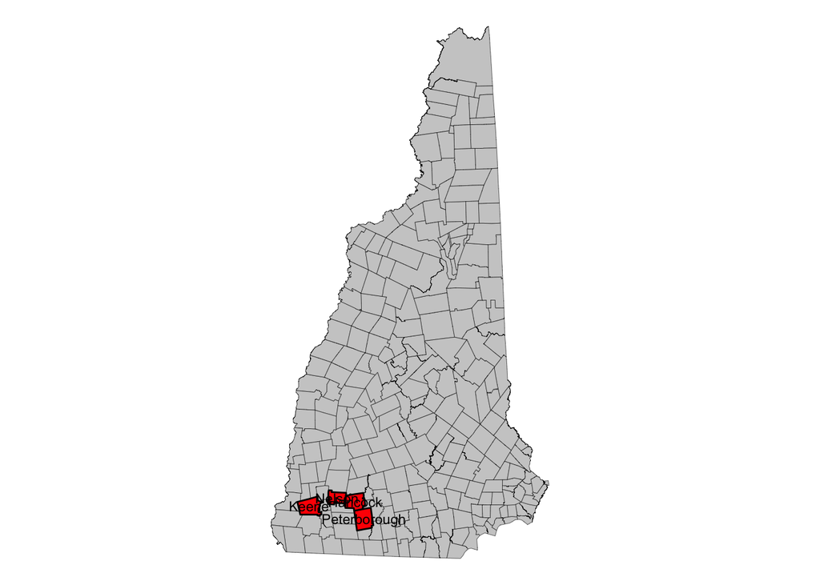

Map of NH with towns that amphibian data was collected from.

**Figure 2:** Eastern Newt

[figure not shown]

**Figure 3:** Wood Frog

[figure not shown]

**Figure 4:** Spring Peeper

[figure not shown]

**Figure 5:** Spotted Salamander

[figure not shown]

# Methods

To visualize the geographic focus of the study, spatial data for New Hampshire’s political boundaries were loaded using the read_sf() function and filtered to include the towns of Hancock, Nelson, Peterborough, and Keene, where amphibian data was collected. A map highlighting these towns was created using ggplot(), with the full state map shown in light gray and the towns of interest marked in red. Labels were added to identify the selected towns, and a minimalistic theme was applied to remove extraneous elements, providing a clear representation of the study area.

Amphibian data, loaded from a CSV file, was cleaned by renaming columns for clarity (e.g., # Dead to Dead, # Crossed to Crossed, Town to TOWN, and Year to year). The cleaned data was merged with the filtered New Hampshire shapefile (nh_filtered) using a left join on the TOWN column, linking the amphibian data to the corresponding towns. The dataset was then filtered to retain only the relevant columns: TOWN, Dead, and town geometries. Land use data was processed by first listing all TIFF files in the “NLCD” directory and filtering those containing “LndCov” in their filenames. The year was extracted from the filenames to create a new vector. A custom function, read_stars2, was defined to read, transform, and crop each land use file using the stars package, ensuring it matched the coordinate reference system of the New Hampshire data and was cropped to the state boundary. The function was applied to each land use dataset using lapply, and the datasets were named based on the extracted year information.

A CSV file containing a land cover legend was loaded, and the landuse column was converted into a factor. A custom function, join_dat, was defined to join the land use data with New Hampshire town boundaries, drop geometry information, and filter the data based on specific development categories. This function was applied to each land use dataset, and the results were combined into one dataframe (nh_lu_combined), which was filtered to remove any missing values.

The development index for each town and year was calculated by grouping the data by town and year, calculating the proportion of each land use category, and applying a score based on the legend. The logarithm of the sum of these scores, weighted by their proportions, formed the final development index for each town-year combination. The amphibian data was processed to ensure consistent year formatting, and the development index was merged with the amphibian data to create a final combined dataset (combined_data), which was filtered to remove missing values.

The analysis involved several statistical techniques to understand the influence of urbanization on amphibian road crossings and mortality. Trends in amphibian mortality rates across years were explored by calculating the ratio of dead to crossed amphibians, with the data differentiated by species. A line graph was created to show how mortality rates changed over time, highlighting the impact of road crossings on amphibian populations.

A random forest model was constructed using the development index (a measure of urbanization), year, species, and town as predictors for the number of amphibian road crossings. This model assessed the relative importance of each predictor in explaining amphibian mortality across towns, with the variable importance plot showing the development index and species as key contributors.

A linear regression model was used to explore the relationship between urbanization and amphibian crossings, incorporating the development index, year, and town as predictors. An interaction term between the development index and year was added to investigate how the effect of urbanization on amphibian crossings may vary over time. The interaction plot illustrated how the development index influenced road crossings differently across years.

To provide a more detailed understanding of town-specific urbanization patterns, the development index trends for Keene, Hancock, Nelson, and Peterborough were examined over time. Graphs for each town were created to show the relationship between the development index and time.

# Results

### Spatial Distribution of Amphibian Mortality

To assess whether amphibian mortality from road crossing is spatially autocorrelated, we produced a map of amphibians dead across Hancock, Peterborough, Nelson, and Keene in New Hampshire.

**Figure 6:** Map of Amphibian Morality Across New Hampshire (NH)

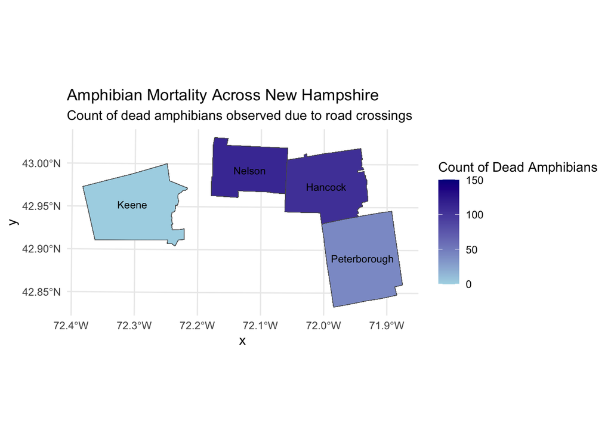

Map of amphibian mortality across New Hampshire, depicting the count of dead amphibians observed due to road crossings. The color gradient indicates the varying number of mortalities, with darker shades representing higher counts. Town names are labeled for reference.

[interactive chart not shown]

### Mortality Trends Over Time

Next, to assess trends in amphibian mortality rates from road crossings across multiple years, we plotted the mortality rates (calculated as the ratio of dead to crossed amphibians) for different species over time. This analysis allows us to explore whether mortality rates have changed over the years, potentially indicating the influence of urbanization on amphibian populations.

**Figure 7:** Amphibian Mortality Rates Over Time for Different Species

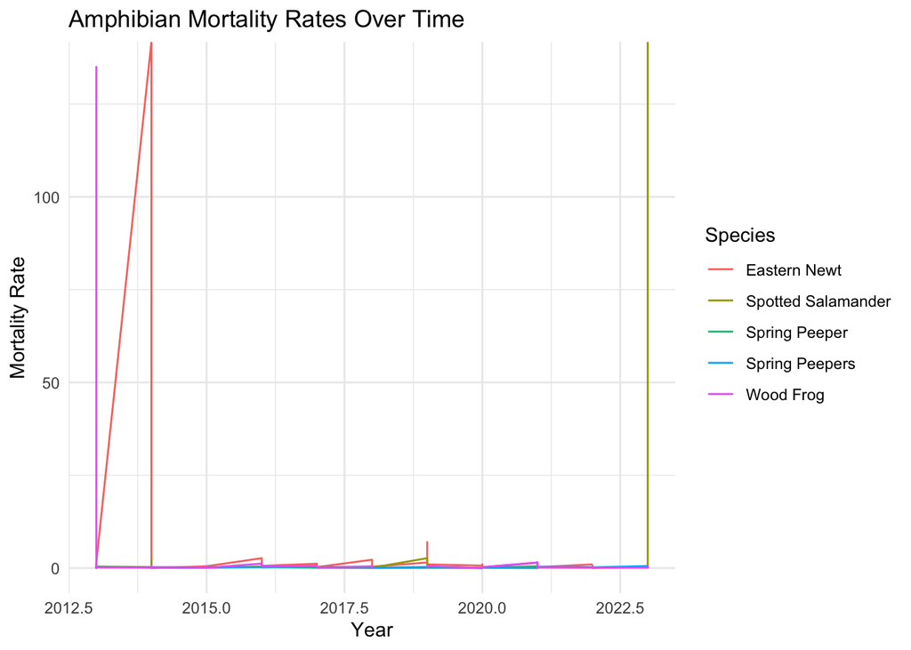

Trends in amphibian mortality rates (ratio of dead to crossed amphibians) across multiple years, differentiated by species. The graph illustrates how mortality rates have changed over time, providing insights into the impact of road crossings on amphibian populations. Higher mortality rates in certain years or species may indicate increased vulnerability, potentially influenced by urbanization.

### Predicting Amphibian Crossing Mortality Based on Land Use: Random Forest and Linear Models

**Figure 8:** Variable Importance Plot from Random Forest Model

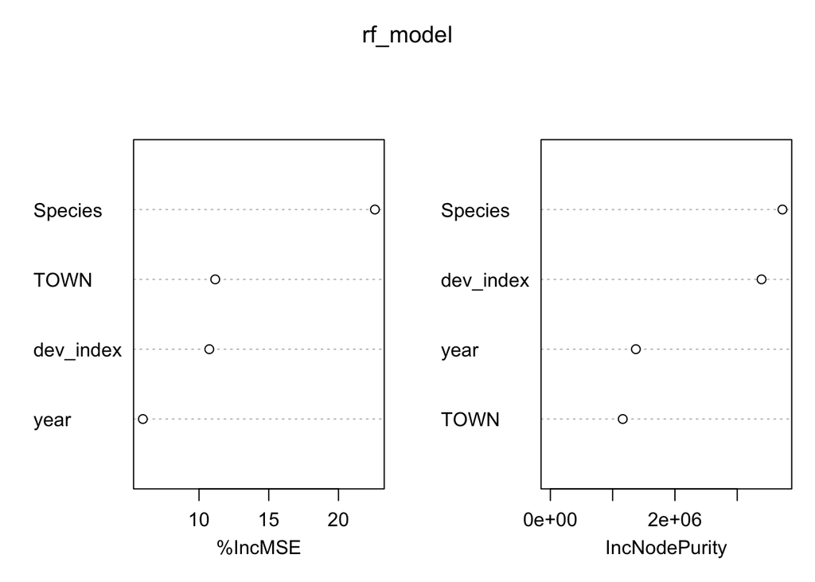

Building on these findings, we then performed a linear regression analysis to further explore how urbanization, along with other variables, directly impacts amphibian road crossings. The linear model allowed us to assess the strength and significance of these predictors in explaining the variation in amphibian crossings across years and towns.

**Figure 9:** Linear Model Results: Amphibian Crossings and Urbanization Factors

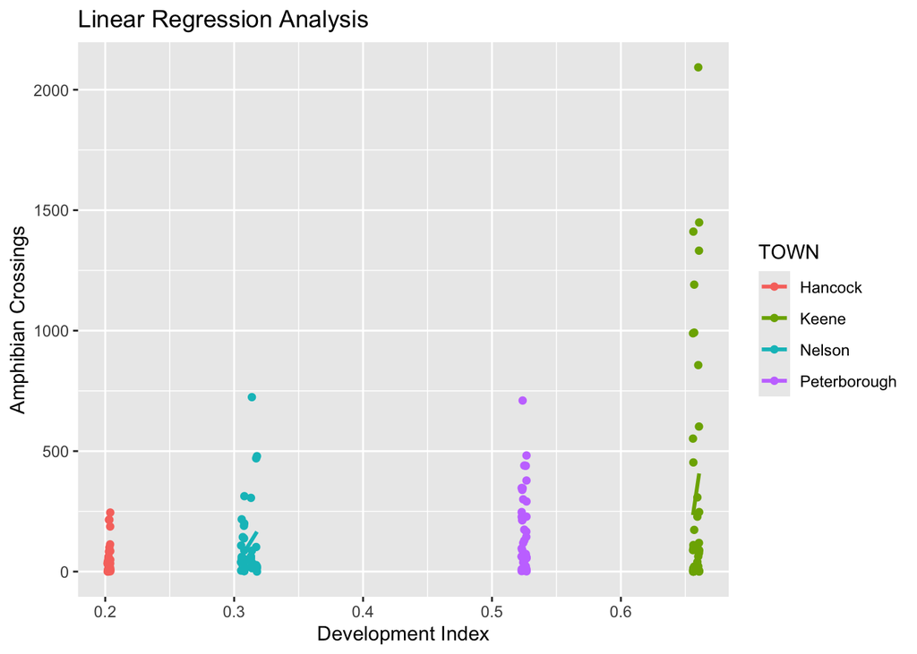

This figure illustrates the relationship between the development index (dev_index) and amphibian road crossings (Crossed) across towns in New Hampshire. Each point represents observed data, with colors distinguishing different towns. The lines show linear regression trends for each town, highlighting variations in amphibian crossings in relation to urbanization levels..

### Understanding Temporal Interactions and Town-Specific Development Trends

To further investigate the interaction between urbanization and time by including an interaction term between the development index and year in the model. This allowed us to investigate how the effect of urbanization on amphibian road crossings may vary over time. The following figure presents the interaction between the development index and year, providing insights into how urbanization’s impact on amphibian crossings changes across different years.

**Figure 10:** Interaction Between Development Index and Year on Amphibian Crossings

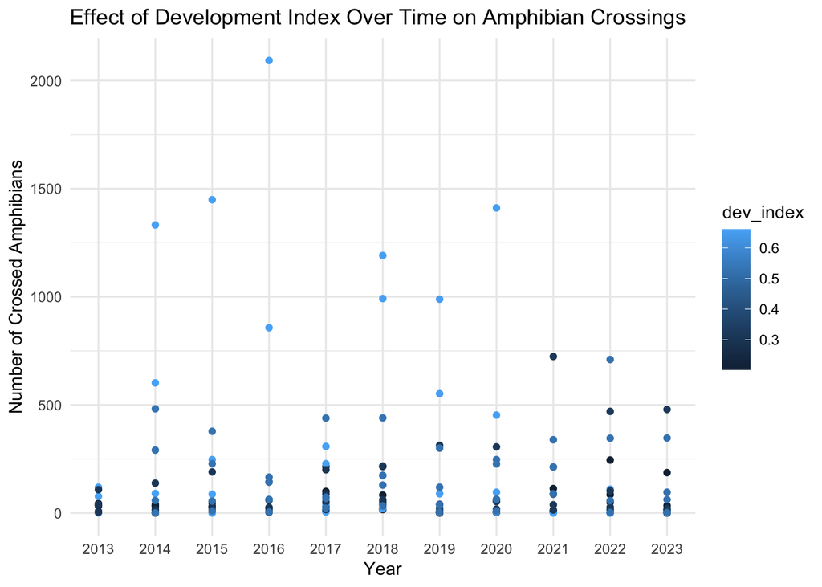

This figure visualizes the interaction between the development index (dev_index) and year in influencing amphibian road crossings. The linear model suggests that the effect of urbanization on amphibian crossings may change over time, with the development index’s influence potentially varying across years. This highlights how urbanization’s impact on amphibian crossings might be stronger or weaker in different years.

Finally, after examining the broader trends of urbanization’s influence on amphibian crossings, we focused on the individual towns of Keene, Hancock, Nelson, and Peterborough to explore how their development index has evolved over time. This allows for a more detailed understanding of the town-specific urbanization patterns that might influence amphibian crossings

**Figure 11:** Development Index Trends Across Towns Over Time

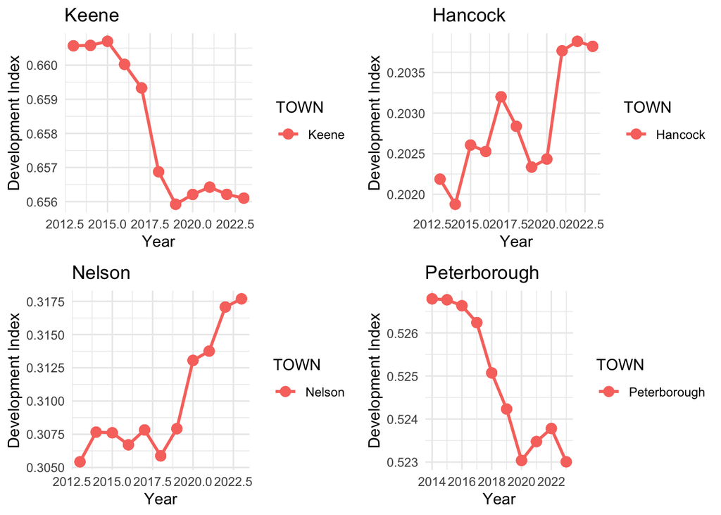

Figure 11 displays the development index trends for four New Hampshire towns (Keene, Hancock, Nelson, and Peterborough) from year to year. The graphs show how urbanization has evolved in these towns, with each plot illustrating the relationship between the development index and time, potentially providing insight into how these urbanization patterns may affect amphibian crossings.

# Author Contributions

# References

Audubon, Mass. 2024. “Big Night: Salamander Migration.” https://www.massaudubon.org/nature-wildlife/reptiles-amphibians/salamanders/big-night.

Beebee, Trevor J. C. 2013. “Effects of Road Mortality and Mitigation Measures on Amphibian Populations.” *Conservation Biology* 27 (4): 657–68. https://doi.org/https://doi.org/10.1111/cobi.12063.

Hamer, Andrew J., and Mark J. McDonnell. 2010. “The Response of Herpetofauna to Urbanization: Inferring Patterns of Persistence from Wildlife Databases.” *Austral Ecology* 35 (5): 568–80. https://doi.org/https://doi.org/10.1111/j.1442-9993.2009.02068.x.

Joyce, Emma. 2024. “What Is Big Night in Spring? How Can You Help Amphibians During This Time?” https://extension.unh.edu/blog/2024/04/what-big-night-spring-how-can-you-help-amphibians-during-time.

Valentine-Darby, Patricia. 2024. “Reptiles and Amphibians: Threats to Survival,” Reptiles and amphibians of the american southwest,. https://www.nps.gov/articles/reptiles-and-amphibians-threats.htm.